# k_eff vs Entropy Tuning

2026-04-17

One-off workbook to calibrate how row entropy maps to an interpretable “effective number of signals” summary for a single `alpha` row.

We construct synthetic `alpha` rows with:

- `p = 1000` total variants
- a high-mass set of size `k`
- `background_mass` spread uniformly across the remaining `p - k` variants

For example, when `k = 2` and `background_mass = 0.1`, the row is:

- `alpha_1 = alpha_2 = 0.45`
- all other variants get `0.1 / 998`

The main tuning question is how the raw row entropy changes as the row behaves more like “mass spread across about `k` variants.”

```r
here::i_am("vignettes/one_off_validations/k_eff_vs_entropy_tuning.Rmd")
library(here)
```

```r
library(dplyr)
library(tidyr)
library(ggplot2)
library(readr)
library(knitr)
theme_set(theme_bw(base_size = 12))
```

## 1 1. Inputs

```r
p <- 1000L
k_grid <- 1:1000
background_mass_grid <- c(0, 0.1, 0.2)

fig_dir <- here("output", "one_off_validations", "k_eff_vs_entropy_tuning")
dir.create(fig_dir, recursive = TRUE, showWarnings = FALSE)

curve_csv <- file.path(fig_dir, "k_eff_vs_entropy_curve.csv")
plot_k_vs_entropy_png <- file.path(fig_dir, "k_vs_entropy.png")
plot_keff_vs_entropy_png <- file.path(fig_dir, "k_eff_vs_entropy.png")
plot_keff_vs_k_png <- file.path(fig_dir, "k_eff_vs_k.png")

cat("p:", p, "\n")
```

```
## p: 1000
```

```r
cat("Figure dir:", fig_dir, "\n")
```

```
## Figure dir: C:/Users/mgcal/OneDrive/Documents/School/Research/Genetics/cTWAS Generalization/Code/test_susine/output/one_off_validations/k_eff_vs_entropy_tuning
```

```r
cat("Curve CSV:", curve_csv, "\n")
```

```
## Curve CSV: C:/Users/mgcal/OneDrive/Documents/School/Research/Genetics/cTWAS Generalization/Code/test_susine/output/one_off_validations/k_eff_vs_entropy_tuning/k_eff_vs_entropy_curve.csv
```

## 2 2. Helpers

```r
xlogx <- function(x) {
  ifelse(x > 0, x * log(x), 0)
}

make_alpha_row <- function(p, k, background_mass) {
  stopifnot(length(p) == 1L, length(k) == 1L, length(background_mass) == 1L)
  stopifnot(k >= 1L, k <= p)
  stopifnot(background_mass >= 0, background_mass < 1)

  if (k == p && background_mass > 0) {
    stop("background_mass > 0 is infeasible when k == p because no background variants remain.")
  }

  alpha <- numeric(p)
  alpha[seq_len(k)] <- (1 - background_mass) / k

  if (k < p && background_mass > 0) {
    alpha[(k + 1):p] <- background_mass / (p - k)
  }

  alpha
}

row_entropy <- function(alpha_row) {
  probs <- alpha_row[alpha_row > 0]
  -sum(probs * log(probs))
}

row_k_eff <- function(alpha_row) {
  exp(row_entropy(alpha_row))
}

compute_row_summary <- function(p, k, background_mass) {
  if (k == p && background_mass > 0) {
    return(NULL)
  }

  main_mass_each <- (1 - background_mass) / k
  background_each <- if (k < p && background_mass > 0) {
    background_mass / (p - k)
  } else {
    0
  }

  entropy <- -(
    k * xlogx(main_mass_each) +
      (p - k) * xlogx(background_each)
  )

  tibble(
    p = p,
    k = k,
    background_mass = background_mass,
    main_mass_each = main_mass_each,
    background_each = background_each,
    entropy = entropy,
    k_eff_entropy = exp(entropy)
  )
}
```

`k_eff_entropy = exp(H)` is the entropy-equivalent support size: the number of equally weighted variants that would have the same entropy.

## 3 3. Build the Tuning Grid

```r
curve_df <- tidyr::expand_grid(
  k = k_grid,
  background_mass = background_mass_grid
) %>%
  dplyr::arrange(.data$background_mass, .data$k)

curve_rows <- lapply(seq_len(nrow(curve_df)), function(i) {
  compute_row_summary(
    p = p,
    k = curve_df$k[[i]],
    background_mass = curve_df$background_mass[[i]]
  )
})

curve_tbl <- dplyr::bind_rows(curve_rows) %>%
  dplyr::mutate(
    background_mass_label = factor(
      .data$background_mass,
      levels = background_mass_grid,
      labels = paste0("background_mass = ", background_mass_grid)
    )
  )

readr::write_csv(curve_tbl, curve_csv)

cat("Rows written:", nrow(curve_tbl), "\n")
```

```
## Rows written: 2998
```

```r
cat("Feasible rows dropped:", nrow(curve_df) - nrow(curve_tbl), "\n")
```

```
## Feasible rows dropped: 2
```

```r
kable(
  curve_tbl %>%
    dplyr::filter(.data$k %in% c(1, 2, 5, 10, 50, 100, 500, 999, 1000)),
  digits = 4
)
```

| p | k | background_mass | main_mass_each | background_each | entropy | k_eff_entropy | background_mass_label |
| --- | --- | --- | --- | --- | --- | --- | --- |
| 1000 | 1 | 0.0 | 1.0000 | 0e+00 | 0.0000 | 1.0000 | background_mass = 0 |
| 1000 | 2 | 0.0 | 0.5000 | 0e+00 | 0.6931 | 2.0000 | background_mass = 0 |
| 1000 | 5 | 0.0 | 0.2000 | 0e+00 | 1.6094 | 5.0000 | background_mass = 0 |
| 1000 | 10 | 0.0 | 0.1000 | 0e+00 | 2.3026 | 10.0000 | background_mass = 0 |
| 1000 | 50 | 0.0 | 0.0200 | 0e+00 | 3.9120 | 50.0000 | background_mass = 0 |
| 1000 | 100 | 0.0 | 0.0100 | 0e+00 | 4.6052 | 100.0000 | background_mass = 0 |
| 1000 | 500 | 0.0 | 0.0020 | 0e+00 | 6.2146 | 500.0000 | background_mass = 0 |
| 1000 | 999 | 0.0 | 0.0010 | 0e+00 | 6.9068 | 999.0000 | background_mass = 0 |
| 1000 | 1000 | 0.0 | 0.0010 | 0e+00 | 6.9078 | 1000.0000 | background_mass = 0 |
| 1000 | 1 | 0.1 | 0.9000 | 1e-04 | 1.0158 | 2.7615 | background_mass = 0.1 |
| 1000 | 2 | 0.1 | 0.4500 | 1e-04 | 1.6395 | 5.1525 | background_mass = 0.1 |
| 1000 | 5 | 0.1 | 0.1800 | 1e-04 | 2.4639 | 11.7500 | background_mass = 0.1 |
| 1000 | 10 | 0.1 | 0.0900 | 1e-04 | 3.0872 | 21.9152 | background_mass = 0.1 |
| 1000 | 50 | 0.1 | 0.0180 | 1e-04 | 4.5315 | 92.9024 | background_mass = 0.1 |
| 1000 | 100 | 0.1 | 0.0090 | 1e-04 | 5.1500 | 172.4273 | background_mass = 0.1 |
| 1000 | 500 | 0.1 | 0.0018 | 2e-04 | 6.5397 | 692.0727 | background_mass = 0.1 |
| 1000 | 999 | 0.1 | 0.0009 | 1e-01 | 6.5412 | 693.0917 | background_mass = 0.1 |
| 1000 | 1 | 0.2 | 0.8000 | 2e-04 | 1.8818 | 6.5650 | background_mass = 0.2 |
| 1000 | 2 | 0.2 | 0.4000 | 2e-04 | 2.4361 | 11.4280 | background_mass = 0.2 |
| 1000 | 5 | 0.2 | 0.1600 | 2e-04 | 3.1685 | 23.7718 | background_mass = 0.2 |
| 1000 | 10 | 0.2 | 0.0800 | 2e-04 | 3.7220 | 41.3475 | background_mass = 0.2 |
| 1000 | 50 | 0.2 | 0.0160 | 2e-04 | 5.0013 | 148.6082 | background_mass = 0.2 |
| 1000 | 100 | 0.2 | 0.0080 | 2e-04 | 5.5450 | 255.9591 | background_mass = 0.2 |
| 1000 | 500 | 0.2 | 0.0016 | 4e-04 | 6.7150 | 824.6924 | background_mass = 0.2 |
| 1000 | 999 | 0.2 | 0.0008 | 2e-01 | 6.0258 | 413.9753 | background_mass = 0.2 |

Feasibility note: when `k = p = 1000`, positive `background_mass` is not possible because there are no non-top-set variants left to hold the background. Those two infeasible rows are omitted.

## 4 4. Spot-Check the Construction

```r
example_alpha <- make_alpha_row(p = 1000L, k = 2L, background_mass = 0.1)

tibble(
  entry = c("alpha[1]", "alpha[2]", "alpha[3]", "sum(alpha)", "entropy", "k_eff_entropy"),
  value = c(
    example_alpha[1],
    example_alpha[2],
    example_alpha[3],
    sum(example_alpha),
    row_entropy(example_alpha),
    row_k_eff(example_alpha)
  )
) %>%
  kable(digits = 6)
```

| entry | value |
| --- | --- |
| alpha[1] | 0.450000 |
| alpha[2] | 0.450000 |
| alpha[3] | 0.000100 |
| sum(alpha) | 1.000000 |
| entropy | 1.639491 |
| k_eff_entropy | 5.152545 |

## 5 5. Plot Entropy vs `k`

Swapped-axis version of the tuning plot: use intended high-mass support size `k` on the x-axis, entropy on the y-axis, and color by `background_mass`.

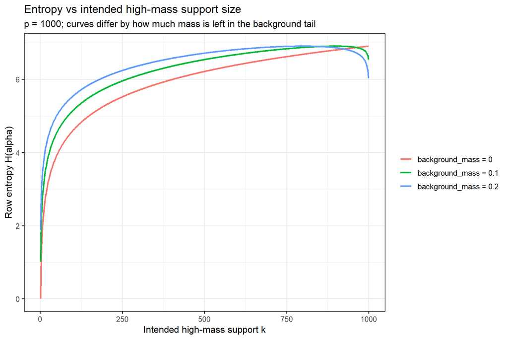

```r
p_k_vs_entropy <- ggplot(
  curve_tbl,
  aes(x = .data$k, y = .data$entropy, color = .data$background_mass_label)
) +
  geom_line(linewidth = 1.0) +
  labs(
    title = "Entropy vs intended high-mass support size",
    subtitle = "p = 1000; curves differ by how much mass is left in the background tail",
    x = "Intended high-mass support k",
    y = "Row entropy H(alpha)",
    color = NULL
  )

print(p_k_vs_entropy)
```

```r
ggsave(
  filename = plot_k_vs_entropy_png,
  plot = p_k_vs_entropy,
  width = 9,
  height = 6,
  dpi = 200
)
```

## 6 6. Why This Is Not One-to-One in `k`

For fixed `background_mass = b`, the synthetic row has entropy

$$H(k, b) =
-(1-b)\log\left(\frac{1-b}{k}\right)
- b\log\left(\frac{b}{p-k}\right)$$

which can be rearranged as

$$H(k, b) =
(1-b)\log(k) + b\log(p-k) - (1-b)\log(1-b) - b\log(b).$$

This shows the key point:

- when `k` increases, the top-set term `((1-b) log k)` pushes entropy up
- but the background term `(b log(p-k))` pushes entropy down because the same background mass is being packed into fewer remaining variants

So for `b > 0`, entropy is generally **not monotone in `k`**. It rises, then falls, with its maximum at

$$k^* = (1-b)p.$$

In this workbook that means:

- `background_mass = 0` peaks at `k = 1000`
- `background_mass = 0.1` peaks at `k = 900`
- `background_mass = 0.2` peaks at `k = 800`

So the current plot should not be expected to be one-to-one in `k`. Two different `k` values can give the same entropy once `background_mass > 0`.

By contrast, if you define

$$k_{\mathrm{eff}} = \exp(H),$$

then `k_eff` and entropy are exactly one-to-one, because `exp()` is a strictly increasing transform.

## 7 7. Plot `k_eff` vs Entropy

This is the direct entropy-to-effective-support mapping.

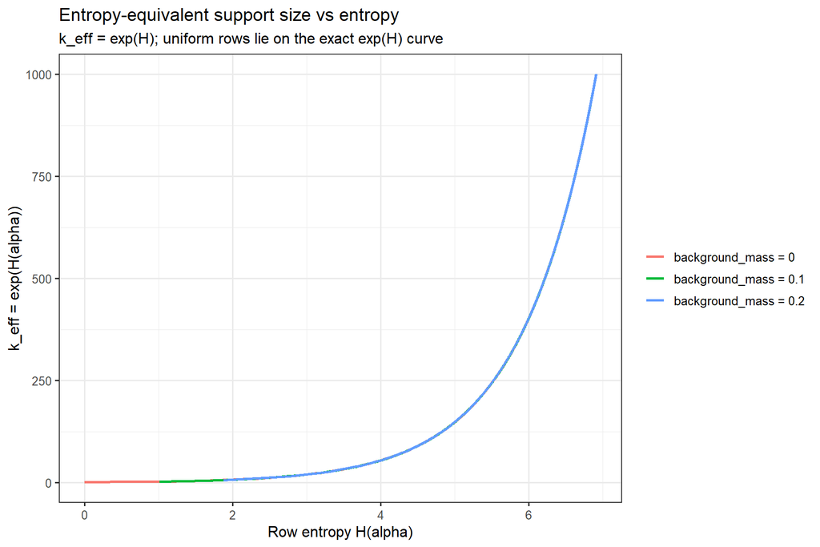

```r
p_keff_vs_entropy <- ggplot(
  curve_tbl,
  aes(x = .data$entropy, y = .data$k_eff_entropy, color = .data$background_mass_label)
) +
  geom_line(linewidth = 1.0) +
  labs(
    title = "Entropy-equivalent support size vs entropy",
    subtitle = "k_eff = exp(H); uniform rows lie on the exact exp(H) curve",
    x = "Row entropy H(alpha)",
    y = "k_eff = exp(H(alpha))",
    color = NULL
  )

print(p_keff_vs_entropy)
```

```r
ggsave(
  filename = plot_keff_vs_entropy_png,
  plot = p_keff_vs_entropy,
  width = 9,
  height = 6,
  dpi = 200
)
```

## 8 8. Plot `k_eff` vs Intended `k`

This view is often the most interpretable for threshold selection: it shows how much the entropy-equivalent support exceeds the nominal high-mass set size once a background tail is introduced.

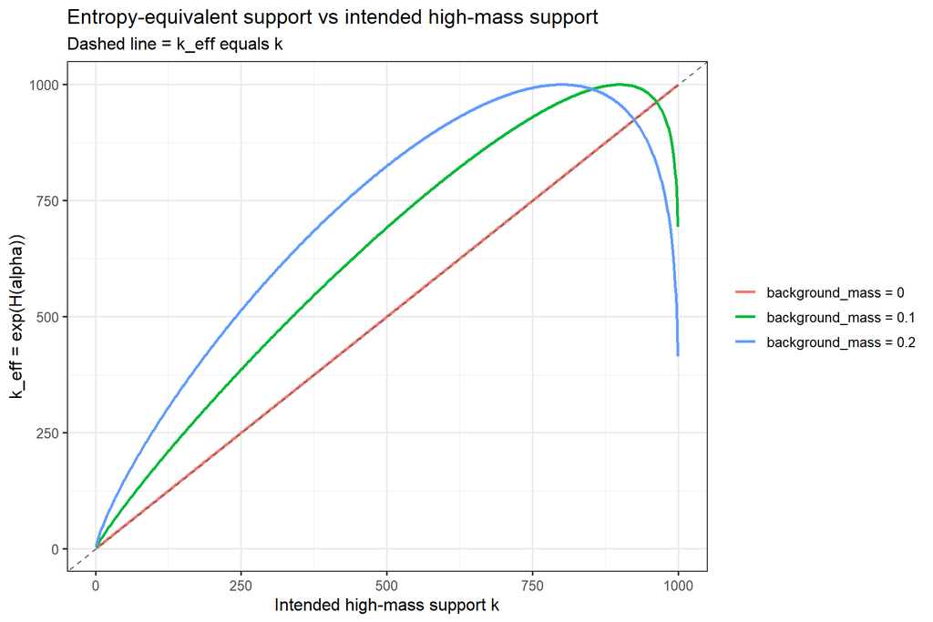

```r
p_keff_vs_k <- ggplot(
  curve_tbl,
  aes(x = .data$k, y = .data$k_eff_entropy, color = .data$background_mass_label)
) +
  geom_line(linewidth = 1.0) +
  geom_abline(slope = 1, intercept = 0, linetype = "dashed", color = "grey40") +
  labs(
    title = "Entropy-equivalent support vs intended high-mass support",
    subtitle = "Dashed line = k_eff equals k",
    x = "Intended high-mass support k",
    y = "k_eff = exp(H(alpha))",
    color = NULL
  )

print(p_keff_vs_k)
```

```r
ggsave(
  filename = plot_keff_vs_k_png,
  plot = p_keff_vs_k,
  width = 9,
  height = 6,
  dpi = 200
)
```

## 9 9. Quick Readout

```r
curve_tbl %>%
  dplyr::filter(.data$k %in% c(2, 5, 10, 20, 50, 100, 200, 500)) %>%
  dplyr::select(.data$k, .data$background_mass, .data$entropy, .data$k_eff_entropy) %>%
  tidyr::pivot_wider(
    names_from = .data$background_mass,
    values_from = c(.data$entropy, .data$k_eff_entropy),
    names_glue = "{.value}_bg{background_mass}"
  ) %>%
  kable(digits = 4)
```

| k | entropy_bg0 | entropy_bg0.1 | entropy_bg0.2 | k_eff_entropy_bg0 | k_eff_entropy_bg0.1 | k_eff_entropy_bg0.2 |
| --- | --- | --- | --- | --- | --- | --- |
| 2 | 0.6931 | 1.6395 | 2.4361 | 2 | 5.1525 | 11.4280 |
| 5 | 1.6094 | 2.4639 | 3.1685 | 5 | 11.7500 | 23.7718 |
| 10 | 2.3026 | 3.0872 | 3.7220 | 10 | 21.9152 | 41.3475 |
| 20 | 2.9957 | 3.7100 | 4.2745 | 20 | 40.8537 | 71.8441 |
| 50 | 3.9120 | 4.5315 | 5.0013 | 50 | 92.9024 | 148.6082 |
| 100 | 4.6052 | 5.1500 | 5.5450 | 100 | 172.4273 | 255.9591 |
| 200 | 5.2983 | 5.7620 | 6.0760 | 200 | 317.9931 | 435.2753 |
| 500 | 6.2146 | 6.5397 | 6.7150 | 500 | 692.0727 | 824.6924 |